# PGA Project 1

```r
knitr::opts_chunk$set(echo = TRUE, eval = TRUE)
```

# Loading and preprocessing the data

```r
library(lubridate)
library(chron)

setwd("C:/Users/silly/Desktop/coursera/Coursera data intro R notes/coursera 5/")
rawdat <- read.csv("activity.csv")
```

# What is mean total number of steps taken per day?

### aggregate data by date (a date stamp uniquely corresponds to a day,

### so the desired per-day statistics can be gathered from such an aggregate).

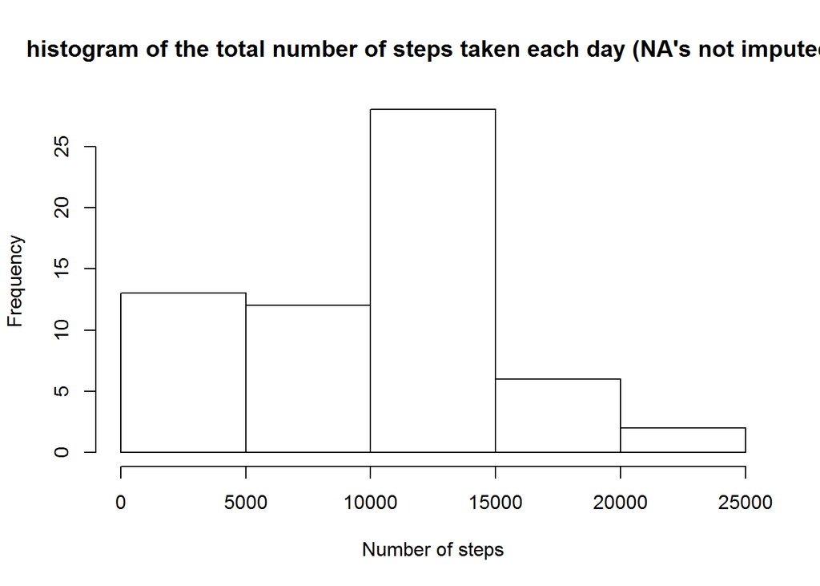

```r
bydate <- data.frame(cbind(rawdat$date,rawdat$steps))
names(bydate) <- c("date","steps")
agg1 <- aggregate(bydate, by=list(bydate$date), FUN=sum, na.rm=TRUE)
hist(agg1$steps,xlab = "Number of steps",
    main = "histogram of the total number of steps taken each day (NA's not imputed)")
```

```r
meanperday <- mean(agg1$steps, na.rm=TRUE)
medianperday <- median(agg1$steps, na.rm=TRUE)
totperday <- sum(agg1$steps, na.rm = TRUE)
print("total of steps per day")
```

```
## [1] "total of steps per day"
```

```r
print(totperday)
```

```
## [1] 570608
```

```r
print("mean value of steps per day")
```

```
## [1] "mean value of steps per day"
```

```r
print(meanperday)
```

```
## [1] 9354.23
```

```r
print("median value of steps per day")
```

```
## [1] "median value of steps per day"
```

```r
print(medianperday)
```

```
## [1] 10395
```

# What is the average daily activity pattern?

### It is assumed the best conversion of seconds to 5 m intervals is to use binning,

### 5 m = 60 s/m * 5 m = 300 s, so, the 5m periods are defined by 300 second buckets.

### The day periods show a max of 2355 seconds, so there are 2355/300 = 8 bin values,

### 8 5-minute segments, arranged to display 0 to 40 minutes in 8 ticks.

```r
val<-NULL
binint <- rawdat

for(i in (1 : dim(binint)[1])){
    c <- binint[i,]$interval
    if(0 <= c & c < 300){val = 1 * 5}
    if(300 <= c & c < 600){val = 2 * 5}
    if(600 <= c & c < 900){val = 3 * 5}
    if(900 <= c & c < 1200){val = 4 * 5}
    if(1200 <= c & c < 1500){val = 5 * 5}
    if(1500 <= c & c < 1800){val = 6 * 5}
    if(1800 <= c & c < 2100){val = 7 * 5}
    if(2100 <= c & c < 2400){val = 8 * 5}
    binint[i,]$interval <- val
}

agg2 <- aggregate(binint, by=list(binint$interval), FUN=mean, na.rm=TRUE)
```

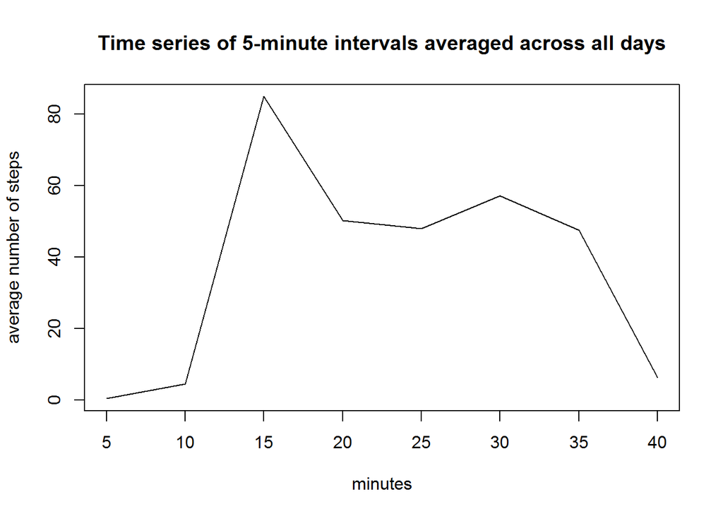

```r
plot(agg2$interval, agg2$steps, type = "l",xlab = "minutes",
     ylab = "average number of steps",
     main = "Time series of 5-minute intervals averaged across all days")
```

```r
print("which interval has the average maximum number of steps")
```

```
## [1] "which interval has the average maximum number of steps"
```

```r
print(which.max(agg2$steps) * 5)
```

```
## [1] 15
```

# Imputing missing values:

### 2. Imputing missing data increases the total daily number of steps.

## How this works:

### This is done by replacing the NA with an average-step number

### for that interval, which occurs by looking up the average

### value for that interval on the aggregate table. This table

### contains averages over steps, aggregated by interval steps.

### A lookup to this table (for the corresponding step average),

### proceeds by passing the specific interval to look up on this

### table from the interval corresponding to the NA value on the

### main table. When a NA is detected in the main-table, the interval

### the NA occurs in, (on the main table) is passed to the interval-

### aggregated table, where the step-average, (recorded on the aggregate

### table) is returned, and assigned to the NA’s storage location on the

### main table, replacing the NA with an estimated step-value. The

### 5 is divided out from the lookup-value passed, as the original table

### is also formatted to show the minute-range for that interval,

### and the aggregate table is indexed by bucket numbers 1-8…

### dividing out the 5 converts the minute-interval to bucket

### number (1-8), and thus the step-average can be referenced by the

### intervals (converted as such), from the originating table. This

### relationship appears below as a nested-table lookup, where the main

### table lookup is nested within the aggregate’s bin index lookup, so that

### lookup values will correlate simultaneously across the aggregate and main

### tables, in one line. This provides a replacement average-steps for

### the NA value, referenced by the interval value in the NA’s row

### (where the interval indexes the aggregate table average steps).

```r
print("number of NA's")
```

```
## [1] "number of NA's"
```

```r
print(sum(is.na(binint$steps)))
```

```
## [1] 2304
```

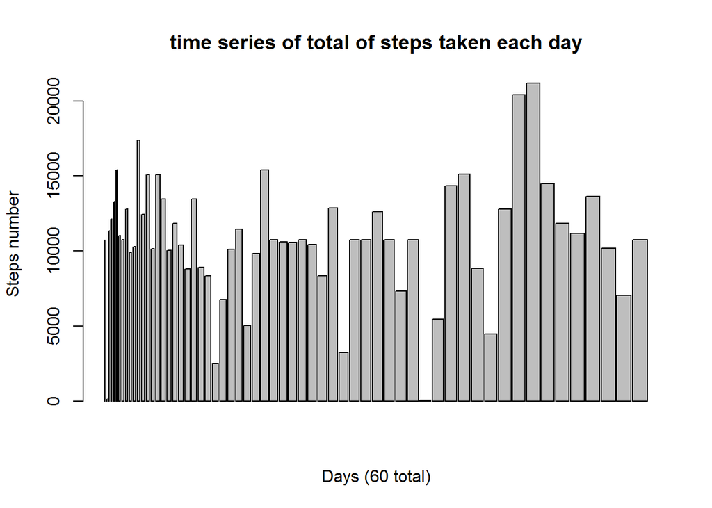

```r
for(i in (1 : dim(binint)[1])){
    if(is.na(binint[i,]$steps)){
        binint[i,]$steps <- agg2[(binint[i,]$interval/5),]$steps
    }
}


new2dat <- data.frame(cbind(binint$steps,rawdat$date,rawdat$interval))
names(new2dat) <- names(rawdat)


agg3 <- aggregate(new2dat, by=list(new2dat$date), FUN=sum, na.rm=FALSE)
barplot(agg3$steps, agg3$date, xlab="Days (60 total)",ylab="Steps number",
        main = "time series of total of steps taken each day")
```

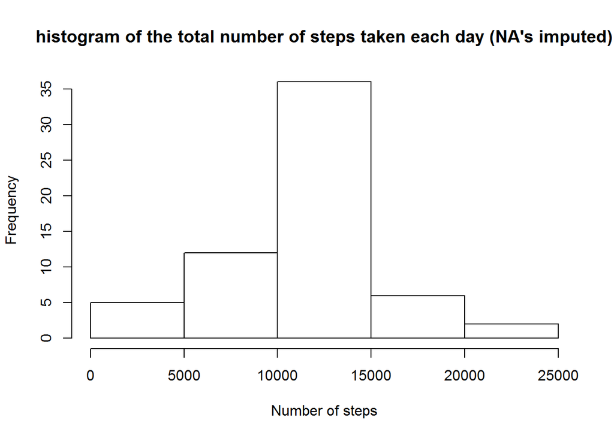

```r
hist(agg3$steps,xlab = "Number of steps",
    main = "histogram of the total number of steps taken each day (NA's imputed)")
```

```r
print("mean total steps per day")
```

```
## [1] "mean total steps per day"
```

```r
print(mean(agg3$steps))
```

```
## [1] 10766.19
```

```r
print("median total steps per day")
```

```
## [1] "median total steps per day"
```

```r
print(median(agg3$steps))
```

```
## [1] 10766.19
```

# Are there differences in activity patterns between weekdays and weekends?

```r
wkndBool <- is.weekend(as.Date(rawdat$date))
wknd <- NULL
wknd[wkndBool] <- "weekend"
wknd[!wkndBool] <- "weekday"

new3dat <- data.frame(cbind(new2dat,binint$interval,wknd))

wknd_dat <- new3dat[new3dat$wknd=="weekend",]
wkdy_dat <- new3dat[new3dat$wknd=="weekday",]

agg4 <- aggregate(wknd_dat, by=list(wknd_dat$binint.interval), FUN=mean, na.rm=TRUE)
agg5 <- aggregate(wkdy_dat, by=list(wkdy_dat$binint.interval), FUN=mean, na.rm=TRUE)
```

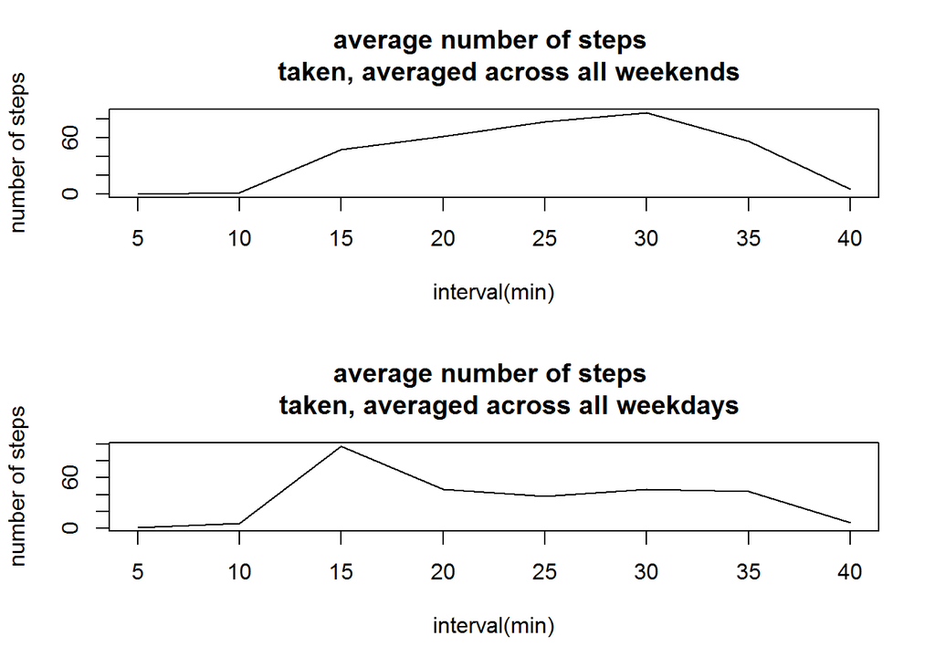

```r
par(mfrow = c(2, 1))
plot(agg4$binint.interval, agg4$steps, type = "l",
     xlab= "interval(min)", ylab = "number of steps", main = "average number of steps
     taken, averaged across all weekends ")

plot(agg5$binint.interval, agg5$steps, type = "l",
     xlab= "interval(min)", ylab = "number of steps", main = "average number of steps
     taken, averaged across all weekdays ")
```

```r
dev.off()
```